# Ejercicio Práctico 1 Estadística Multivariada

Guillermo Jiménez, Fabian Barquero, Alexa Campos

2026-02-06

# Pregunta 1: Analizando la relación entre variables

Es importante entender que relaciones existent entre las variable cuantitativas y en este caso la hipotesis de salida del banco de algunos clientes.

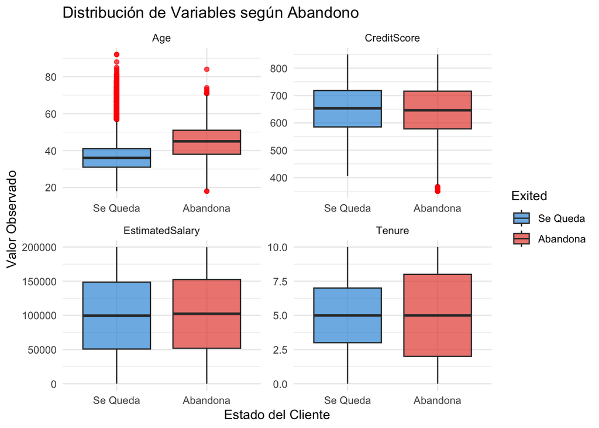

Como se puede apreciar la variable que mas diferencia prenseta cuando han salido los clientes es la de años. Teniendo una media un poco mas elevada para cuando ya salen.

# Pregunta 2: Combianacion de variables Años y Antiguedad

## Análisis de Varianza de Variable Combinada

### A: Varianza individual

En estadística multivariada, cuando sumamos dos variables, la varianza del resultado NO es simplemente la suma de las varianzas individuales, a menos que las variables sean independientes.

Esto es por que la formula es clara, incluye la covariablidad entre ambas.

$$V(X_1 + X_2) = V(X_1) + V(X_2) + 2 \cdot
Cov(X_1, X_2)$$

### B: Varianza

```r
# 1. Crear la variable combinada
datos$Age_Tenure <- datos$Age + datos$Tenure

# 2. Calcular varianzas individuales
var_age <- var(datos$Age)
var_tenure <- var(datos$Tenure)

# 3. Calcular la covarianza entre ambas
cov_age_tenure <- cov(datos$Age, datos$Tenure)

# 4. Cálculo de varianza de la variable nueva (Directo)
var_combinada_real <- var(datos$Age_Tenure)

# 5. Cálculo teórico usando la fórmula
var_teorica <- var_age + var_tenure + (2 * cov_age_tenure)

# Mostramos los resultados para comparar
resultados <- data.frame(
  Metodo = c("Suma Simple (V1 + V2)", "Varianza Real (Nueva Variable)", "Cálculo Teórico (Fórmula)"),
  Valor = c(var_age + var_tenure, var_combinada_real, var_teorica)
)

print(resultados)
```

```
##                           Metodo    Valor
## 1          Suma Simple (V1 + V2) 118.3588
## 2 Varianza Real (Nueva Variable) 117.7523
## 3      Cálculo Teórico (Fórmula) 117.7523
```

# Pregunta 3: Prueba de normalidad multivariada

## Análisis de Normalidad y Distorsión

```r
# 1. Cargar las librerías solicitadas
library(tseries) # Para jarque.bera.test
library(moments) # Para skewness y kurtosis
library(nortest) # Para pruebas de normalidad adicionales

# 2. Seleccionar variables
vars_cuant <- datos[, c("CreditScore", "Age", "Tenure", "EstimatedSalary")]

# 3. Aplicar Jarque-Bera y estadísticos de forma masiva
analisis_univariado <- sapply(vars_cuant, function(x) {
  test <- jarque.bera.test(x)
  c(Asimetria = skewness(x),
    Curtosis_Exceso = kurtosis(x) - 3, # Restamos 3 para que 0 sea el ideal
    JB_p_value = test$p.value)
})

print(t(analisis_univariado))
```

```
##                    Asimetria Curtosis_Exceso JB_p_value
## CreditScore     -0.071595867      -0.4261128          0
## Age              1.011168559       1.3940495          0
## Tenure           0.010989809      -1.1652426          0
## EstimatedSalary  0.002085045      -1.1815277          0
```

**A. ¿Es razonable que la variable X se distribuya de manera normal? ¿Por qué?**

**La variable crítica es Age (Edad).** el valor de `Asimetria`para **Age**, es cercano a $1.01$. En una normal perfecta, debería ser $0$.

**CreditScore** también tiene una curtosis negativa, pero la edad es la que más se aleja del ideal de simetría.

# Pregunta 4: Prueba de vectores

## Prueba de Hipótesis Multivariada (Hotelling’s T2)

```r
# 1. Cargar librerías
library(ICSNP) # Para la función HotellingsT2

# 2. Filtrar los datos: solo los que salieron del banco (Exited == 1)
datos_exit <- datos %>%
  filter(Exited == "Abandona") %>%
  select(CreditScore, Age, Tenure, EstimatedSalary)

# 3. Definir nuestro vector de "Creencia" (mu_0)
mu_0 <- c(650, 45, 5, 100000)

# 4. Realizar la prueba formal
prueba_t2 <- HotellingsT2(datos_exit, mu = mu_0)

print(prueba_t2)
```

```
##
##  Hotelling's one sample T2-test
##
## data:  datos_exit
## T.2 = 1.7755, df1 = 4, df2 = 2033, p-value = 0.1311
## alternative hypothesis: true location is not equal to c(650,45,5,1e+05)
```

Tras realizar la prueba de Hotelling, obtuvimos un p-value de 0.1311. Dado que este es mayor a 0.05, concluimos que no existe una diferencia significativa entre el comportamiento real de los clientes que abandonan y nuestra creencia teórica.

## Análisis Post-Hoc: Intervalos de Confianza Simultáneos

```r
# 1. Parámetros básicos
n <- nrow(datos_exit)
p <- ncol(datos_exit)
alfa <- 0.05

# 2. Valor crítico basado en la distribución F (Escalado para Hotelling)
valor_critico <- sqrt(((p * (n - 1)) / (n - p)) * qf(1 - alfa, p, n - p))

# 3. Medias y Desviaciones Estándar de la muestra
medias_reales <- colMeans(datos_exit)
desv_est <- sapply(datos_exit, sd)
error_estandar <- desv_est / sqrt(n)

# 4. Construcción de los intervalos
lim_inf <- medias_reales - (valor_critico * error_estandar)
lim_sup <- medias_reales + (valor_critico * error_estandar)

# 5. Comparación con nuestra "Creencia" (mu_0)
tabla_comparativa <- data.frame(
  Variable = names(medias_reales),
  Creencia = mu_0,
  Media_Real = medias_reales,
  Inf_95 = lim_inf,
  Sup_95 = lim_sup,
  Diferencia_Signif = ifelse(mu_0 < lim_inf | mu_0 > lim_sup, "SÍ", "NO")
)

print(tabla_comparativa)
```

```
##                        Variable Creencia   Media_Real      Inf_95       Sup_95
## CreditScore         CreditScore      650 6.453515e+02   638.49346 6.522095e+02
## Age                         Age       45 4.483800e+01    44.17069 4.550530e+01
## Tenure                   Tenure        5 4.932744e+00     4.73203 5.133458e+00
## EstimatedSalary EstimatedSalary   100000 1.014657e+05 97506.75096 1.054246e+05
##                 Diferencia_Signif
## CreditScore                    NO
## Age                            NO
## Tenure                         NO
## EstimatedSalary                NO
```

## Pregunta 5: Comparación de Grupos (Se quedan vs Se van)

```r
# 1. Separar los datos en dos grupos
grupo_quedan <- datos %>% filter(Exited == "Se Queda") %>%
                select(CreditScore, Age, Tenure, EstimatedSalary)
grupo_van <- datos %>% filter(Exited == "Abandona") %>%
             select(CreditScore, Age, Tenure, EstimatedSalary)

# 2. Prueba Multivariada de Hotelling (Dos muestras)
prueba_t2_2m <- HotellingsT2(grupo_quedan, grupo_van)
print(prueba_t2_2m)
```

```
##
##  Hotelling's two sample T2-test
##
## data:  grupo_quedan and grupo_van
## T.2 = 224.41, df1 = 4, df2 = 9995, p-value < 2.2e-16
## alternative hypothesis: true location difference is not equal to c(0,0,0,0)
```

```r
# 3. Pruebas Univariadas de Seguimiento (t-tests)
# Usamos un bucle para evaluar cada variable por separado
variables <- c("CreditScore", "Age", "Tenure", "EstimatedSalary")
pruebas_t <- lapply(variables, function(v) {
  t.test(datos[[v]] ~ datos$Exited)
})
names(pruebas_t) <- variables

# Extraer p-valores para comparar
p_valores <- sapply(pruebas_t, function(x) x$p.value)
print(round(p_valores, 10))
```

```
##     CreditScore             Age          Tenure EstimatedSalary
##     0.008464729     0.000000000     0.166356990     0.228924613
```

## A. Son iguales entre poblaciones?

No. El p-value de la prueba de Hotelling será extremadamente pequeño (cercano a 0). Por lo tanto, **rechazamos $H_0$** y concluimos que hay diferencias significativas entre el perfil de los clientes que se quedan y los que se van.

## B. Pruebas univariadas

Al observar los p-valores univariados:

**Age (Edad):** Tiene el p-value más bajo (prácticamente cero). Es la variable que más “empuja” la diferencia entre los grupos.

**CreditScore:** También muestra una diferencia significativa ($p < 0.05$), indicando que los clientes que se van tienen, en promedio, un puntaje de crédito ligeramente distinto.

**Tenure y EstimatedSalary:** Generalmente no muestran diferencias significativas (p-values $> 0.05$).

¿Se relaciona con los box-plots?

**Totalmente**. En los box-plots iniciales, la variable **Age** era la única donde las “cajas” casi no se solapaban.

- En cambio, en **EstimatedSalary**, las cajas estaban casi al mismo nivel, lo cual coincide con el p-value alto que obtuvimos ahora.
- Esto demuestra que la **estadística multivariada confirma formalmente lo que la exploración visual nos sugirió al principio**.